# Rembrandt Vignette

Jalal Siddiqui

5/20/2020

## Using Rembrandt

This Rmarkdown document will illustrate some of the features of the REMBRANDT R package.

Rembrandt can be installed using the following code:

```r
library(devtools)
install_github("MilesLab/Rembrandt")
```

After Rembrandt is installed, we can load in the packages as below.

```r
library(Rembrandt)
```

Rembrant includes several files in the package. We can identify them as below.

```r
list.files(system.file("extdata", package = "Rembrandt"))
```

```
## [1] "COVID_seqs.fa"             "covid.saf"
## [3] "patient_barcode_table.csv" "simulation_actual.csv"
## [5] "test_data_1.fq"            "test_data_2.fq"
## [7] "test.forward.barcodes.csv" "test.reverse.barcodes.csv"
```

A description of the important files will be as follows.

## The ‘COVID_seqs.fa’ amplicon sequences file

The **COVID_seqs.fa** is a fasta file that contains the amplicon sequences. From here we can build an index to perform alignments.

We can obtain the path of the file as follows.

```r
covid_seqs_path = system.file("extdata","COVID_seqs.fa", package = "Rembrandt")
```

Using *cat* in command line, we can visualize these files.

```
cat COVID_seqs.fa
```

```
## >N1_SARS_COV2
## GACCCCAAAATCAGCGAAATGCACCCCGCATTACGTTTGGTGGACCCTCAGATTCAACTGGCAGTAACCAGAATGGAGAA
CGC
## >RNAseP
## GATTTGGACCTGCGAGCGGGTTCTGACCTGAAGGCTCTGCGCGGACTTGTGGAGACAGCCGCTC
```

## The ‘covid.saf’ annotation file

The **covid.saf** is a simplified annotation file that will be used for determining feature counts. It essentially is the amplicons and their coordinates.

The path of the file is as below.

```r
covid_saf_path = system.file("extdata","covid.saf", package = "Rembrandt")
```

The file contents are shown as below.

```r
read.table(covid_saf_path,header = T)
```

```
##         GeneID          Chr Start End Strand
## 1 N1_SARS_COV2 N1_SARS_COV2     1  83      +
## 2       RNAseP       RNAseP     1  64      +
```

## The test data

We have included files as a test dataset. This will be run as an example.

The ‘fastq’ files **test_data_1.fq** and **test_data_2.fq** are the paired-end test files. Rembrandt requires paired end files.

We can import the paths of these files as follows.

```r
test_data_1_path = system.file("extdata","test_data_1.fq", package = "Rembrandt")
test_data_2_path = system.file("extdata","test_data_2.fq", package = "Rembrandt")
```

In command line, we can preview the files as follows.

```
cat test_data_1.fq | head
```

```
## @Sequence:1:Read1
## TGTAAAACGACGGCCAGTTCTCGCCTGACCCCAAAATCAGCGAAATGCACCCCGCATTACGTTTGGTGGACCCTCAGATTCAACTGGCAGTAACCAGAATGGAGAACGCTTTGGGAGGTCATAGCTGTTTCCTG
## +
## KKKKKKKKKKKKKKKKKKKKKKKKKKKKKKKKKKKKKKKKKKKKKKKKKKKKKKKKKKKKKKKKKKKKKKKKKKKKKKKKKKKKKKKKKKKKKKKKKKKKKKKKKKKKKKKKKKKKKKKKKKKKKKKKKKKKKK
## @Sequence:2:Read1
## TGTAAAACGACGGCCAGTTCTCGCCTGACCCCAAAATCAGCGAAATGCACCCCGCATTACGTTTGGTGGACCCTCAGATTCAACTGGCAGTAACCAGAATGGAGAACGCTTTGGGAGGTCATAGCTGTTTCCTG
## +
## KKKKKKKKKKKKKKKKKKKKKKKKKKKKKKKKKKKKKKKKKKKKKKKKKKKKKKKKKKKKKKKKKKKKKKKKKKKKKKKKKKKKKKKKKKKKKKKKKKKKKKKKKKKKKKKKKKKKKKKKKKKKKKKKKKKKKK
## @Sequence:3:Read1
## TGTAAAACGACGGCCAGTTCTCGCCTGACCCCAAAATCAGCGAAATGCACCCCGCATTACGTTTGGTGGACCCTCAGATTCAACTGGCAGTAACCAGAATGGAGAACGCTTTGGGAGGTCATAGCTGTTTCCTG
```

```
cat test_data_2.fq | head
```

```
## @Sequence:1:Read2
## CAGGAAACAGCTATGACCTCCCAAAGCGTTCTCCATTCTGGTTACTGCCAGTTGAATCTGAGGGTCCACCAAACGTAATGCGGGGTGCATTTCGCTGATTTTGGGGTCAGGCGAGAACTGGCCGTCGTTTTACA
## +
## KKKKKKKKKKKKKKKKKKKKKKKKKKKKKKKKKKKKKKKKKKKKKKKKKKKKKKKKKKKKKKKKKKKKKKKKKKKKKKKKKKKKKKKKKKKKKKKKKKKKKKKKKKKKKKKKKKKKKKKKKKKKKKKKKKKKKK
## @Sequence:2:Read2
## CAGGAAACAGCTATGACCTCCCAAAGCGTTCTCCATTCTGGTTACTGCCAGTTGAATCTGAGGGTCCACCAAACGTAATGCGGGGTGCATTTCGCTGATTTTGGGGTCAGGCGAGAACTGGCCGTCGTTTTACA
## +
## KKKKKKKKKKKKKKKKKKKKKKKKKKKKKKKKKKKKKKKKKKKKKKKKKKKKKKKKKKKKKKKKKKKKKKKKKKKKKKKKKKKKKKKKKKKKKKKKKKKKKKKKKKKKKKKKKKKKKKKKKKKKKKKKKKKKKK
## @Sequence:3:Read2
## CAGGAAACAGCTATGACCTCCCAAAGCGTTCTCCATTCTGGTTACTGCCAGTTGAATCTGAGGGTCCACCAAACGTAATGCGGGGTGCATTTCGCTGATTTTGGGGTCAGGCGAGAACTGGCCGTCGTTTTACA
```

The files each contain 2336 reads each which makes them readily available for a quick test analysis.  
The next set of files are the test barcodes files. They contain the list of barcodes.

This is the **test.forward.barcodes.csv** and the **test.reverse.barcodes.csv**.

These are the list of barcodes for the test data.

The forward barcodes are as follows.

```r
test.forward.barcodes.path = system.file("extdata","test.forward.barcodes.csv", package = "Rembrandt")
test.forward.barcodes = read.table(test.forward.barcodes.path,header = T, stringsAsFactors = F)
test.forward.barcodes = test.forward.barcodes$barcodes
test.forward.barcodes
```

```
## [1] "TCTCGCCT" "AGGTCTCC" "TCCGTCAA" "AACTGAGC" "GACTCGCA"
```

The reverse barcodes are as follows.

```r
test.reverse.barcodes.path = system.file("extdata","test.reverse.barcodes.csv", package = "Rembrandt")
test.reverse.barcodes = read.table(test.reverse.barcodes.path,header = T, stringsAsFactors = F)
test.reverse.barcodes = test.reverse.barcodes$barcodes
test.reverse.barcodes
```

```
## [1] "CTCCCAAA" "TCCATTCA" "AAAGCTCG" "GTTAACGG" "TGCGTTAC"
```

We also have a file linking patient ID to the pairs of barcodes. We can store the path and preview the files as follows.

```r
patient_barcode_table_path = system.file("extdata","patient_barcode_table.csv", package = "Rembrandt")
patient_barcode_table = read.csv(patient_barcode_table_path,header = T, stringsAsFactors = F)
patient_barcode_table
```

```
##    patient_id plate_barcode well_barcode
## 1   patient_1      TCTCGCCT     CTCCCAAA
## 2   patient_2      TCTCGCCT     TCCATTCA
## 3   patient_3      TCTCGCCT     AAAGCTCG
## 4   patient_4      TCTCGCCT     GTTAACGG
## 5   patient_5      TCTCGCCT     TGCGTTAC
## 6   patient_6      AGGTCTCC     CTCCCAAA
## 7   patient_7      AGGTCTCC     TCCATTCA
## 8   patient_8      AGGTCTCC     AAAGCTCG
## 9   patient_9      AGGTCTCC     GTTAACGG
## 10 patient_10      AGGTCTCC     TGCGTTAC
## 11 patient_11      TCCGTCAA     CTCCCAAA
## 12 patient_12      TCCGTCAA     TCCATTCA
## 13 patient_13      TCCGTCAA     AAAGCTCG
## 14 patient_14      TCCGTCAA     GTTAACGG
## 15 patient_15      TCCGTCAA     TGCGTTAC
## 16 patient_16      AACTGAGC     CTCCCAAA
## 17 patient_17      AACTGAGC     TCCATTCA
## 18 patient_18      AACTGAGC     AAAGCTCG
## 19 patient_19      AACTGAGC     GTTAACGG
## 20 patient_20      AACTGAGC     TGCGTTAC
## 21 patient_21      GACTCGCA     CTCCCAAA
## 22 patient_22      GACTCGCA     TCCATTCA
## 23 patient_23      GACTCGCA     AAAGCTCG
## 24 patient_24      GACTCGCA     GTTAACGG
## 25 patient_25      GACTCGCA     TGCGTTAC
```

## Processing the reads

We are now ready to start processing of the reads.

The first step is to create a temporary directory for this vignette purposes.

```r
dir.create("temp_vignette")
list.files("temp_vignette")
```

```
## character(0)
```

The first step will be to de-multiplex the reads by the forward or plate barcodes.**nreads** is the number of reads that will be iterated through by the **yield()** functions from the **ShortRead** package.

```r
summary.plate.split = split_plate_barcodes(pair1_filepath = test_data_1_path,
                                           pair2_filepath = test_data_2_path,nreads = 100,
                                           forward_barcode = test.forward.barcodes,
                                           output_prefix = "temp_vignette/plate_demultiplexed")
```

The newly split files are as below.

```r
list.files("temp_vignette")
```

```
##  [1] "plate_demultiplexed_split_AACTGAGC_1.fq"
##  [2] "plate_demultiplexed_split_AACTGAGC_2.fq"
##  [3] "plate_demultiplexed_split_AGGTCTCC_1.fq"
##  [4] "plate_demultiplexed_split_AGGTCTCC_2.fq"
##  [5] "plate_demultiplexed_split_GACTCGCA_1.fq"
##  [6] "plate_demultiplexed_split_GACTCGCA_2.fq"
##  [7] "plate_demultiplexed_split_TCCGTCAA_1.fq"
##  [8] "plate_demultiplexed_split_TCCGTCAA_2.fq"
##  [9] "plate_demultiplexed_split_TCTCGCCT_1.fq"
## [10] "plate_demultiplexed_split_TCTCGCCT_2.fq"
```

Of note, the **summary.plate.split** variable from the *split_plate_barcodes()* function lists the files and the barcodes that splits the file.

This is shown as below.

```r
summary.plate.split[,3:5]
```

```
##   forward_barcode                               forward_barcoded_files1
## 1        TCTCGCCT temp_vignette/plate_demultiplexed_split_TCTCGCCT_1.fq
## 2        AGGTCTCC temp_vignette/plate_demultiplexed_split_AGGTCTCC_1.fq
## 3        TCCGTCAA temp_vignette/plate_demultiplexed_split_TCCGTCAA_1.fq
## 4        AACTGAGC temp_vignette/plate_demultiplexed_split_AACTGAGC_1.fq
## 5        GACTCGCA temp_vignette/plate_demultiplexed_split_GACTCGCA_1.fq
##                                 forward_barcoded_files2
## 1 temp_vignette/plate_demultiplexed_split_TCTCGCCT_2.fq
## 2 temp_vignette/plate_demultiplexed_split_AGGTCTCC_2.fq
## 3 temp_vignette/plate_demultiplexed_split_TCCGTCAA_2.fq
## 4 temp_vignette/plate_demultiplexed_split_AACTGAGC_2.fq
## 5 temp_vignette/plate_demultiplexed_split_GACTCGCA_2.fq
```

The plate demultiplexed barcoded files can be obtained as below.

```r
plate_demultiplexed_files1 = summary.plate.split$forward_barcoded_files1
plate_demultiplexed_files2 = summary.plate.split$forward_barcoded_files2
plate_demultiplexed_files1
```

```
## [1] "temp_vignette/plate_demultiplexed_split_TCTCGCCT_1.fq"
## [2] "temp_vignette/plate_demultiplexed_split_AGGTCTCC_1.fq"
## [3] "temp_vignette/plate_demultiplexed_split_TCCGTCAA_1.fq"
## [4] "temp_vignette/plate_demultiplexed_split_AACTGAGC_1.fq"
## [5] "temp_vignette/plate_demultiplexed_split_GACTCGCA_1.fq"
```

```r
plate_demultiplexed_files2
```

```
## [1] "temp_vignette/plate_demultiplexed_split_TCTCGCCT_2.fq"
## [2] "temp_vignette/plate_demultiplexed_split_AGGTCTCC_2.fq"
## [3] "temp_vignette/plate_demultiplexed_split_TCCGTCAA_2.fq"
## [4] "temp_vignette/plate_demultiplexed_split_AACTGAGC_2.fq"
## [5] "temp_vignette/plate_demultiplexed_split_GACTCGCA_2.fq"
```

A for-loop is run over each of these resulting files for the reverse or well-specific split. The newly created files are as follows.

```r
summary.well.split.list = list()
for(i in 1:length(plate_demultiplexed_files1)){
output.prefix = gsub(x = plate_demultiplexed_files1[i], pattern = "_1.fq", replacement = "")
output.prefix = paste(output.prefix, "_well_demultiplexed", sep = "")
summary.well.split.list[[i]] = split_well_barcodes(pair1_filepath = plate_demultiplexed_files1[i],
                                           pair2_filepath = plate_demultiplexed_files2[i],
                                           nreads = 100,
                                           reverse_barcode = test.reverse.barcodes,
                                           output_prefix = output.prefix)
}
list.files("temp_vignette")
```

```
##  [1] "plate_demultiplexed_split_AACTGAGC_1.fq"
##  [2] "plate_demultiplexed_split_AACTGAGC_2.fq"
##  [3] "plate_demultiplexed_split_AACTGAGC_well_demultiplexed_split_AAAGCTCG_1.fq"
##  [4] "plate_demultiplexed_split_AACTGAGC_well_demultiplexed_split_AAAGCTCG_2.fq"
##  [5] "plate_demultiplexed_split_AACTGAGC_well_demultiplexed_split_CTCCCAAA_1.fq"
##  [6] "plate_demultiplexed_split_AACTGAGC_well_demultiplexed_split_CTCCCAAA_2.fq"
##  [7] "plate_demultiplexed_split_AACTGAGC_well_demultiplexed_split_GTTAACGG_1.fq"
##  [8] "plate_demultiplexed_split_AACTGAGC_well_demultiplexed_split_GTTAACGG_2.fq"
##  [9] "plate_demultiplexed_split_AACTGAGC_well_demultiplexed_split_TCCATTCA_1.fq"
## [10] "plate_demultiplexed_split_AACTGAGC_well_demultiplexed_split_TCCATTCA_2.fq"
## [11] "plate_demultiplexed_split_AACTGAGC_well_demultiplexed_split_TGCGTTAC_1.fq"
## [12] "plate_demultiplexed_split_AACTGAGC_well_demultiplexed_split_TGCGTTAC_2.fq"
## [13] "plate_demultiplexed_split_AGGTCTCC_1.fq"
## [14] "plate_demultiplexed_split_AGGTCTCC_2.fq"
## [15] "plate_demultiplexed_split_AGGTCTCC_well_demultiplexed_split_AAAGCTCG_1.fq"
```

[output cut: 45 more lines]

Again we can see the files as split by their barcodes.

```r
all.well.split.files = do.call(rbind,summary.well.split.list)[,3:5]
head(all.well.split.files)
```

```
##   reverse_barcode
## 1        CTCCCAAA
## 2        TCCATTCA
## 3        AAAGCTCG
## 4        GTTAACGG
## 5        TGCGTTAC
## 6        CTCCCAAA
##                                                                   reverse_barcoded_files1
## 1 temp_vignette/plate_demultiplexed_split_TCTCGCCT_well_demultiplexed_split_CTCCCAAA_1.fq
## 2 temp_vignette/plate_demultiplexed_split_TCTCGCCT_well_demultiplexed_split_TCCATTCA_1.fq
## 3 temp_vignette/plate_demultiplexed_split_TCTCGCCT_well_demultiplexed_split_AAAGCTCG_1.fq
## 4 temp_vignette/plate_demultiplexed_split_TCTCGCCT_well_demultiplexed_split_GTTAACGG_1.fq
## 5 temp_vignette/plate_demultiplexed_split_TCTCGCCT_well_demultiplexed_split_TGCGTTAC_1.fq
## 6 temp_vignette/plate_demultiplexed_split_AGGTCTCC_well_demultiplexed_split_CTCCCAAA_1.fq
##                                                                   reverse_barcoded_files2
## 1 temp_vignette/plate_demultiplexed_split_TCTCGCCT_well_demultiplexed_split_CTCCCAAA_2.fq
## 2 temp_vignette/plate_demultiplexed_split_TCTCGCCT_well_demultiplexed_split_TCCATTCA_2.fq
## 3 temp_vignette/plate_demultiplexed_split_TCTCGCCT_well_demultiplexed_split_AAAGCTCG_2.fq
## 4 temp_vignette/plate_demultiplexed_split_TCTCGCCT_well_demultiplexed_split_GTTAACGG_2.fq
## 5 temp_vignette/plate_demultiplexed_split_TCTCGCCT_well_demultiplexed_split_TGCGTTAC_2.fq
## 6 temp_vignette/plate_demultiplexed_split_AGGTCTCC_well_demultiplexed_split_CTCCCAAA_2.fq
```

We can obtain a list of these final files.

```r
final_to_align_1 = as.character(all.well.split.files$reverse_barcoded_files1)
final_to_align_2 = as.character(all.well.split.files$reverse_barcoded_files2)
```

## Aligning the reads

The next step is to align the resulting fastq files to the amplicon sequences. This will be done using the *Rsubread* package.

We can build an index for the COVID amplicons as below using the **covid_seqs_path** path for the fasta file.

```r
dir.create("temp_vignette/alignment_index")
Rsubread::buildindex('temp_vignette/alignment_index/COVID_amplicon_index',reference = covid_seqs_path)
```

[output not shown]

[output cut: 220 more lines]

[output not shown]

```r
list.files("temp_vignette/alignment_index")
```

```
## [1] "COVID_amplicon_index.00.b.array" "COVID_amplicon_index.00.b.tab"
## [3] "COVID_amplicon_index.files"      "COVID_amplicon_index.log"
## [5] "COVID_amplicon_index.reads"
```

After building the index, we can align the files as follows.

```r
dir.create("temp_vignette/alignment_results")
output_bam_files = c()

for(i in 1:length(final_to_align_1)){
  output.file = gsub(x = final_to_align_1[i], pattern = "_1.fq", replacement = "")
  output.file = gsub(x = output.file, pattern = "temp_vignette/", replacement = "")
  output.file = paste("temp_vignette/alignment_results/",
                      output.file, "_aligned.bam", sep = "")
  output_bam_files[i] = output.file

}

Rsubread::align(index = "temp_vignette/alignment_index/COVID_amplicon_index",
                readfile1 = final_to_align_1,
                readfile2 = final_to_align_2,
                output_file = output_bam_files,
                input_format = "FASTQ")
```

[output not shown]

[output cut: 1744 more lines]

[output not shown]

```
##                           Category
## 1                  Total_fragments
## 2                 Mapped_fragments
## 3        Uniquely_mapped_fragments
## 4          Multi_mapping_fragments
## 5               Unmapped_fragments
## 6        Properly_paired_fragments
## 7              Singleton_fragments
## 8      More_than_one_chr_fragments
## 9  Unexpected_strandness_fragments
## 10      Unexpected_template_length
## 11                Inversed_mapping
## 12                          Indels
##    temp_vignette/alignment_results/plate_demultiplexed_split_TCTCGCCT_well_demultiplexed_split_CTCCCAAA_aligned.bam
## 1                                                                                                               146
```

[output cut: 323 more lines]

```r
list.files("temp_vignette/alignment_results")
```

```
##  [1] "plate_demultiplexed_split_AACTGAGC_well_demultiplexed_split_AAAGCTCG_aligned.bam"
##  [2] "plate_demultiplexed_split_AACTGAGC_well_demultiplexed_split_AAAGCTCG_aligned.bam.indel.vcf"
##  [3] "plate_demultiplexed_split_AACTGAGC_well_demultiplexed_split_CTCCCAAA_aligned.bam"
##  [4] "plate_demultiplexed_split_AACTGAGC_well_demultiplexed_split_CTCCCAAA_aligned.bam.indel.vcf"
##  [5] "plate_demultiplexed_split_AACTGAGC_well_demultiplexed_split_GTTAACGG_aligned.bam"
##  [6] "plate_demultiplexed_split_AACTGAGC_well_demultiplexed_split_GTTAACGG_aligned.bam.indel.vcf"
##  [7] "plate_demultiplexed_split_AACTGAGC_well_demultiplexed_split_TCCATTCA_aligned.bam"
##  [8] "plate_demultiplexed_split_AACTGAGC_well_demultiplexed_split_TCCATTCA_aligned.bam.indel.vcf"
##  [9] "plate_demultiplexed_split_AACTGAGC_well_demultiplexed_split_TGCGTTAC_aligned.bam"
## [10] "plate_demultiplexed_split_AACTGAGC_well_demultiplexed_split_TGCGTTAC_aligned.bam.indel.vcf"
## [11] "plate_demultiplexed_split_AGGTCTCC_well_demultiplexed_split_AAAGCTCG_aligned.bam"
## [12] "plate_demultiplexed_split_AGGTCTCC_well_demultiplexed_split_AAAGCTCG_aligned.bam.indel.vcf"
## [13] "plate_demultiplexed_split_AGGTCTCC_well_demultiplexed_split_CTCCCAAA_aligned.bam"
## [14] "plate_demultiplexed_split_AGGTCTCC_well_demultiplexed_split_CTCCCAAA_aligned.bam.indel.vcf"
## [15] "plate_demultiplexed_split_AGGTCTCC_well_demultiplexed_split_GTTAACGG_aligned.bam"
```

[output cut: 35 more lines]

The final step is to obtain feature counts for the resulting files

```r
fc.alignments = Rsubread::featureCounts(files = output_bam_files, annot.ext = covid_saf_path)
```

[output not shown]

[output cut: 178 more lines]

[output not shown]

```r
names(fc.alignments)
```

```
## [1] "counts"     "annotation" "targets"    "stat"
```

We can store the counts information into the following matrix.

```r
fc.counts = fc.alignments$counts
fc.samples = colnames(fc.counts)

patient.index = c()
for(i in 1:nrow(patient_barcode_table)){
  patient.index[i] = intersect(grep(pattern = as.character(patient_barcode_table$plate_barcode[i]),
                x = fc.samples),
            grep(pattern = as.character(patient_barcode_table$well_barcode[i]),
                 x = fc.samples))
  fc.samples[patient.index[i]] = as.character(patient_barcode_table$patient_id[i])
}
fc.samples
```

```
##  [1] "patient_1"  "patient_2"  "patient_3"  "patient_4"  "patient_5"
##  [6] "patient_6"  "patient_7"  "patient_8"  "patient_9"  "patient_10"
## [11] "patient_11" "patient_12" "patient_13" "patient_14" "patient_15"
## [16] "patient_16" "patient_17" "patient_18" "patient_19" "patient_20"
## [21] "patient_21" "patient_22" "patient_23" "patient_24" "patient_25"
```

```r
colnames(fc.counts) = fc.samples
```

The counts for the patients are as below.

```r
t(fc.counts)
```

```
##            N1_SARS_COV2 RNAseP
## patient_1           140    152
## patient_2           110     42
## patient_3            58     52
## patient_4           186    200
## patient_5            60    162
## patient_6           168    112
## patient_7            58    130
## patient_8            54     64
## patient_9            38    126
## patient_10           48     66
## patient_11           64    102
## patient_12           62    136
## patient_13           32     98
## patient_14            8     50
## patient_15           44    154
## patient_16          164     16
## patient_17          106     62
## patient_18          184    144
## patient_19          168    102
## patient_20           10     32
## patient_21           92    102
## patient_22           54    100
## patient_23           62    152
## patient_24          102     36
## patient_25           38    170
```

We can extract information on the simulated reads.

```r
simulation_path = system.file("extdata","simulation_actual.csv", package = "Rembrandt")
simulated_counts = as.matrix(read.csv(simulation_path, row.names = 1))
t(simulated_counts)
```

```
##            N1_SARS_COV2 RNAseP
## patient_1            70     76
## patient_2            55     21
## patient_3            29     26
## patient_4            93    100
## patient_5            30     81
## patient_6            84     56
## patient_7            29     65
## patient_8            27     32
## patient_9            19     63
## patient_10           24     33
## patient_11           32     51
## patient_12           31     68
## patient_13           16     49
## patient_14            4     25
## patient_15           22     77
## patient_16           82      8
## patient_17           53     31
## patient_18           92     72
## patient_19           84     51
## patient_20            5     16
## patient_21           46     51
## patient_22           27     50
## patient_23           31     76
## patient_24           51     18
## patient_25           19     85
```

These can be compared to our featureCounts

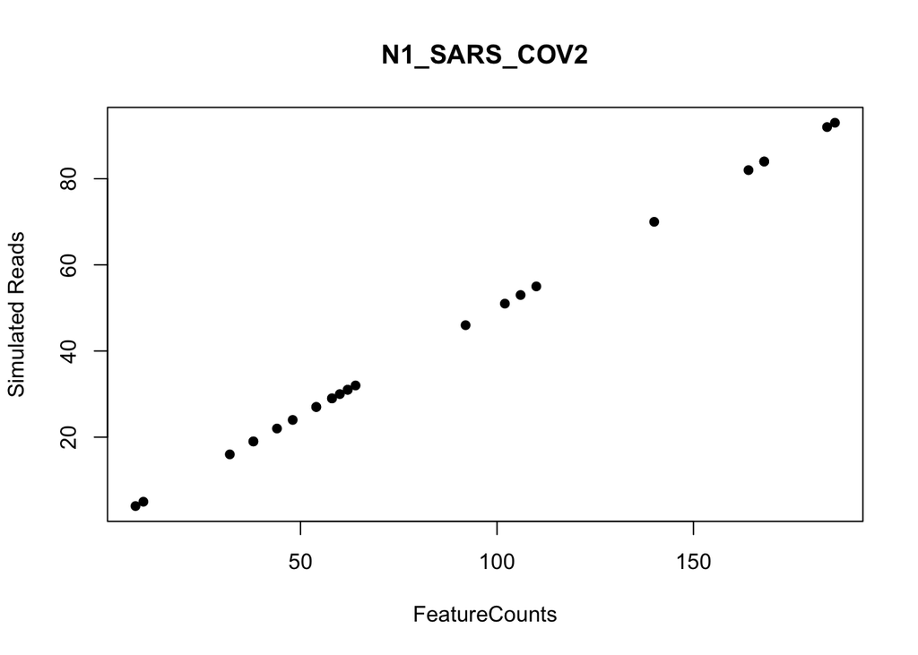

```r
plot(t(fc.counts)[,1], t(simulated_counts)[,1],xlab = "FeatureCounts", ylab = "Simulated Reads",
     main = "N1_SARS_COV2", pch = 16)
```

```r
cor(t(fc.counts)[,1],t(simulated_counts)[,1])
```

```
## [1] 1
```

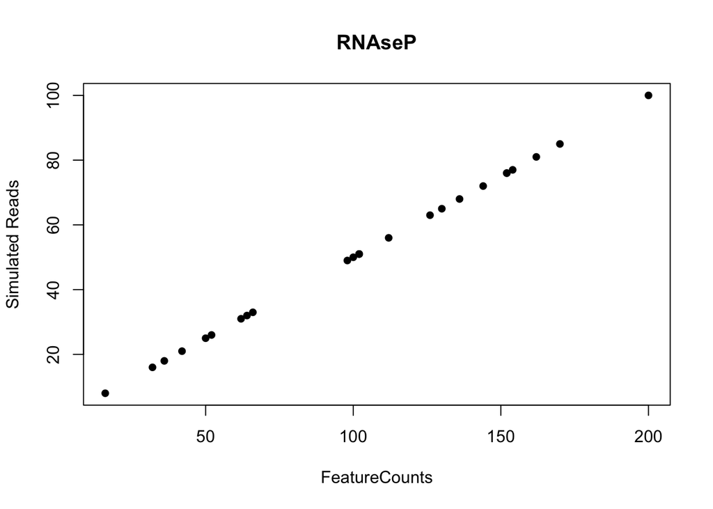

```r
plot(t(fc.counts)[,2], t(simulated_counts)[,2],xlab = "FeatureCounts", ylab = "Simulated Reads",
     main = "RNAseP", pch = 16)
```

```r
cor(t(fc.counts)[,2],t(simulated_counts)[,2])
```

```
## [1] 1
```

We can also compare N1_SARS_COV2/RNAseP ratios.

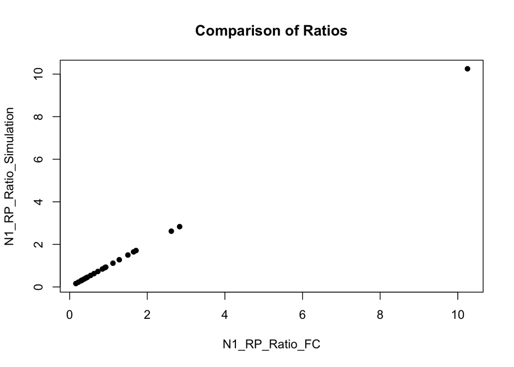

```r
N1_RP_Ratio_FC = t(fc.counts)[,1]/t(fc.counts)[,2]
N1_RP_Ratio_Simulation = t(simulated_counts)[,1]/t(simulated_counts)[,2]

plot(N1_RP_Ratio_FC,N1_RP_Ratio_Simulation,pch = 16,
     main = "Comparison of Ratios")
```

```r
cor(N1_RP_Ratio_FC,N1_RP_Ratio_Simulation)
```

```
## [1] 1
```